# Analyzing loan data from Prosper

Jae Hee Lee

September, 2016

```
## [1] "C:/Users/Jae Hee/Documents/Udacity/Data Analysis with R/Project/data"
```

## About Data

#### Background: What is Propser and peer-to-peer (P2P) lending system?

> Prosper is a peer-to-peer lending marketplace, where borrowers list loan requests between $2,000 and $35,000 and individual lenders invest as little as $25 in each loan listing they select. It is Prosper that handles the servicing of the loan on behalf of the matched borrowers and investors. Assuming I would like to borrow or invest money, I would like to test the viability of this site. That is, would this site be beneficial to me? Would I be able to use this system? In other words, who can really use this system?

#### Important details about Propser P2P lending system

- Each loan is assigned a risk rating from AA (lower risk, lower return) to HR (higher risk, higher return) (AA (4.38%), A (5.08%), B (6.07%), C (7.58%), D (9.73%), E (11.35%), HR (11.13% = Estimated Returns)) [CreditGrade / PropserRating Variable]
- For the best borrowers, the starting APR is 5.99% but really depends on the borrower’s purpose and credit quality as well.

## Objective

By analyzing the dataset, I would like to explore these questions in detail and see what answers this dataset would give for each question.

- What is the number of investors for each loan? [I would be able to know how ‘active’ the platform is. If the number is small, then it suggests that the platform is inactive]
- Are investors friends of a user? [If most of the investors are friends, then this can also indicate that the platform is not active.]
- Which state has the high portion of Prosper users? [I do not live in the U.S but this can sort of give information about who is actually using the system. Are they generally rich or poor?]
- What is the ratio of # of users who is not a home owner to # of users owning a house [again, this can give information about the profile of Prosper users].
- What is the most frequent income range of users? [I would like to compare with my salary to decide whether to use this platform]
- What is the most frequent listing? [It is highly likely that I will use this platform for the personal loan but would like to see why people use this platform]
- Would occupation / employment status / current delinquencies matter?
- Is employability correlated with estimated loss / yield / return ? [In case of charge-off, would my employability be related with the amount of estimated loss? what would be the return? [difference between yield and loss]]
- Is employability correlated with loan status / delinquencies?

After considering these questions, I would like to draw final summary using three final plots (which are multivariate) to determine whether to use this platform or not. One important caveat before delving into analysis is that the data may show correlation but not causation.

## Univariate Analysis

By analyzing how many investors each loan entry attracts, we might be able to see how active the platform is.

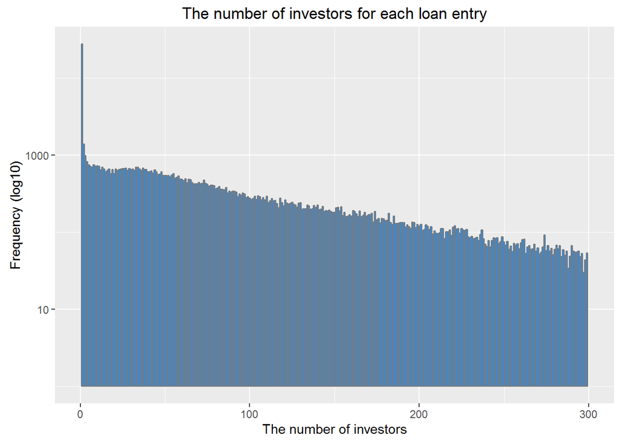

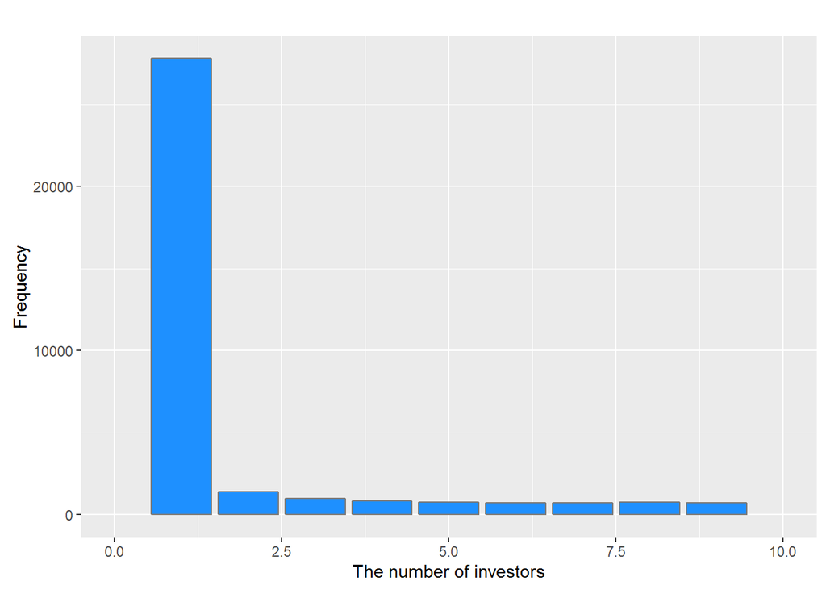

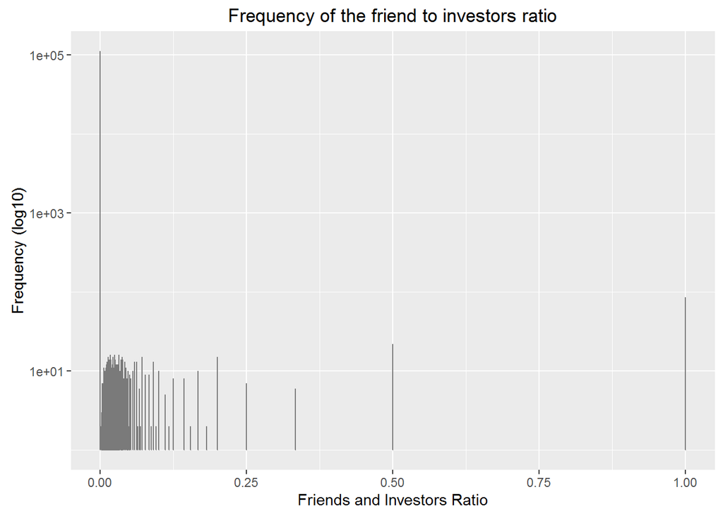

Now I would like to know the distribution of borrowers according to the states in the US. My initial guess or hypothesis would be that more people from relatively low socioeconomic areas would use this system than those from rich areas.

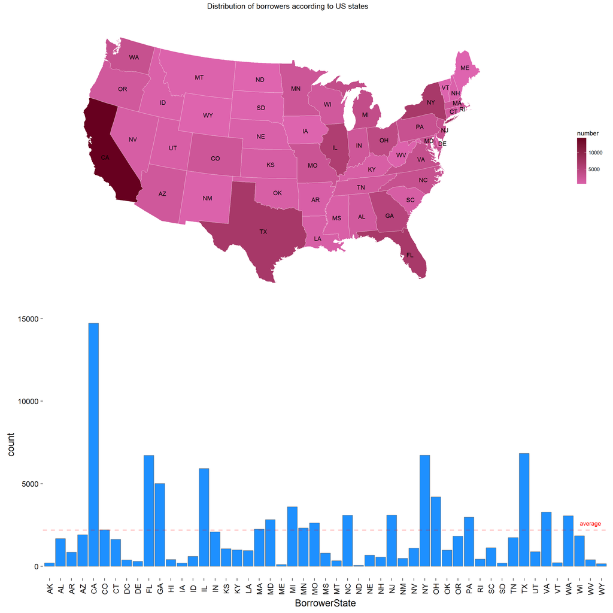

Now, I would like to get some details from users to decide whether to use the platform or not.

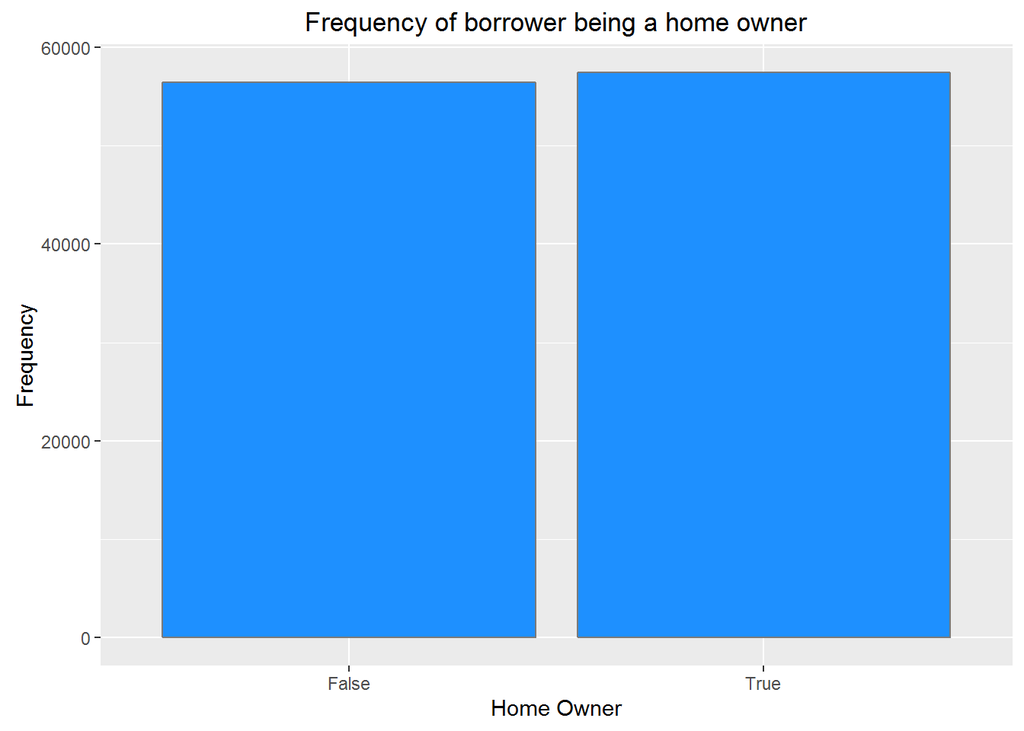

We can see that the number of borrowers who are home owners is almost the same as the number of borrows who does not own a home.

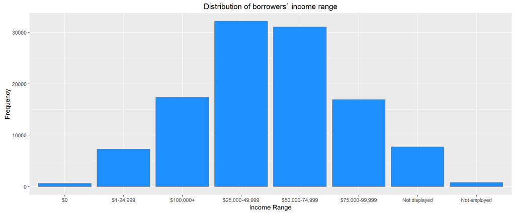

From this graph, we can see that people with the average income usually borrow money.

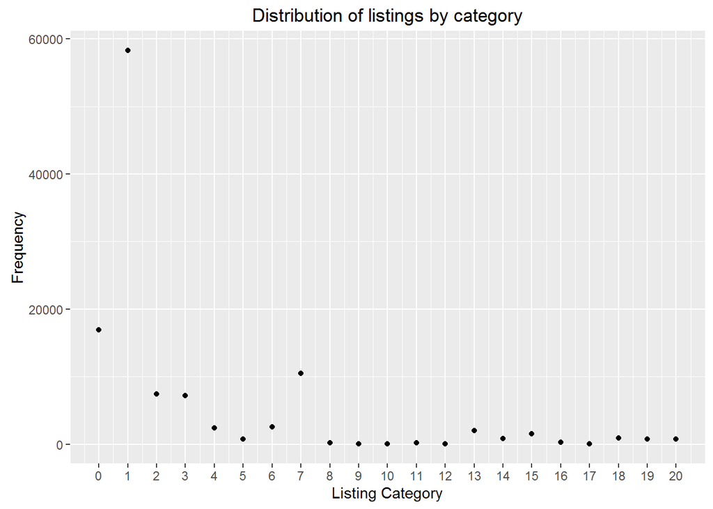

From this graph, we can see that most people use the platform for debt consolidation and this is not my purpose of borrowing money.

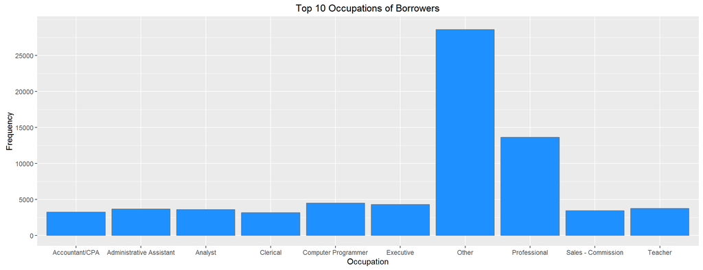

By looking at this graph, we can see that the occupation and being a borrower are not correlated.

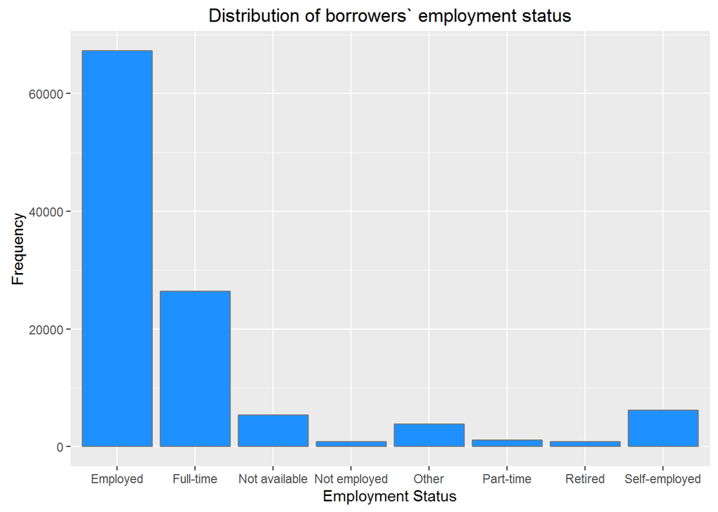

Most users are in fact employed.

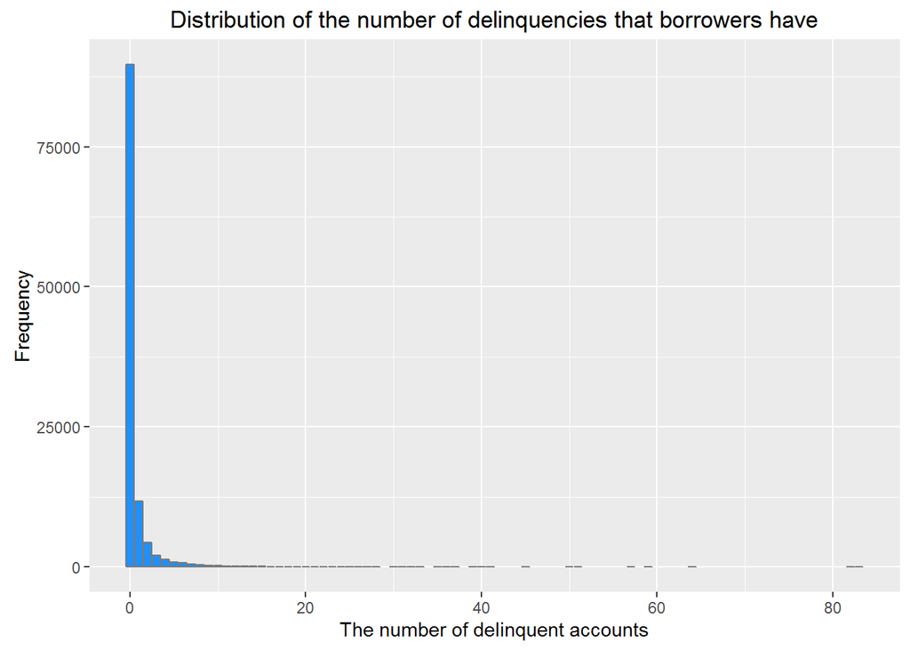

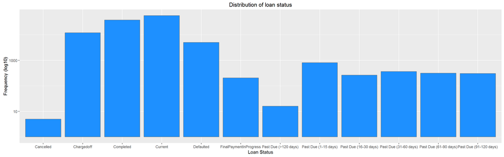

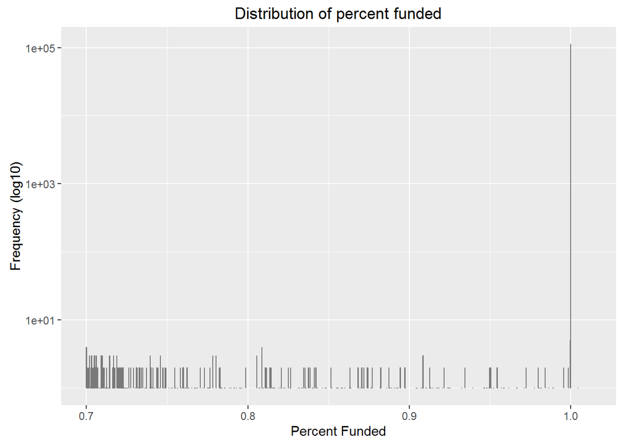

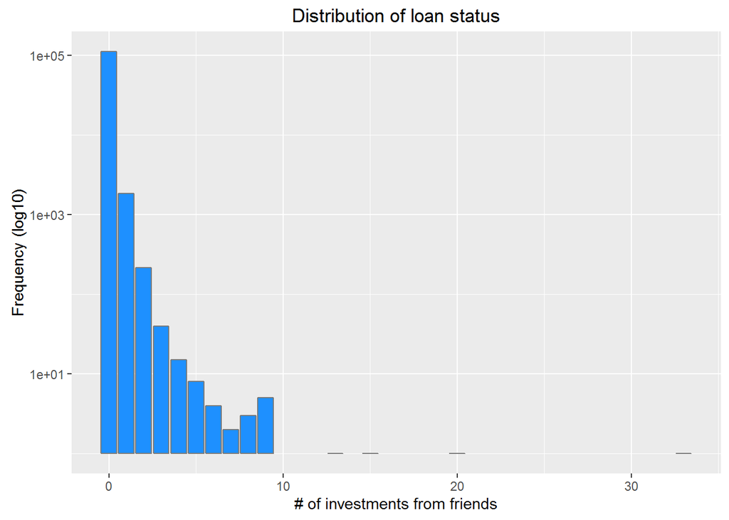

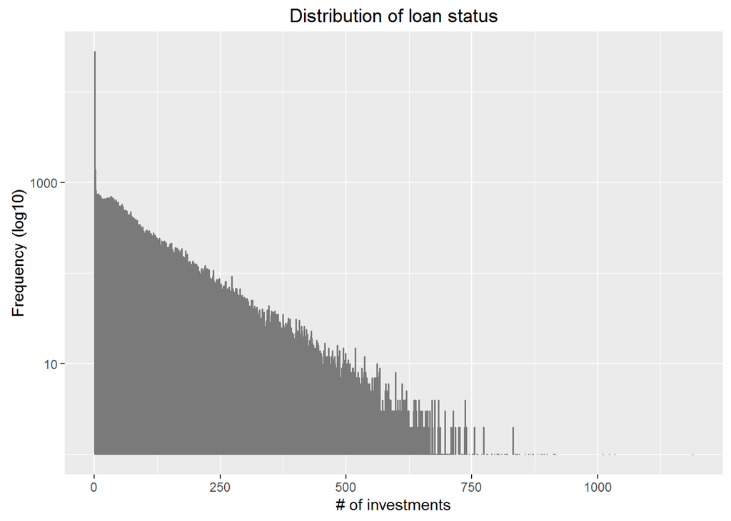

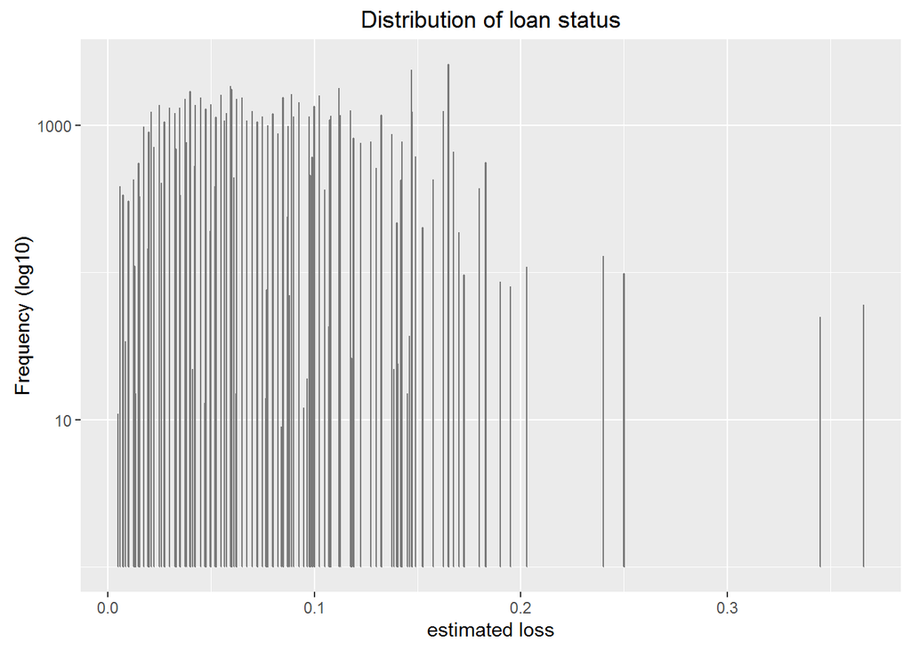

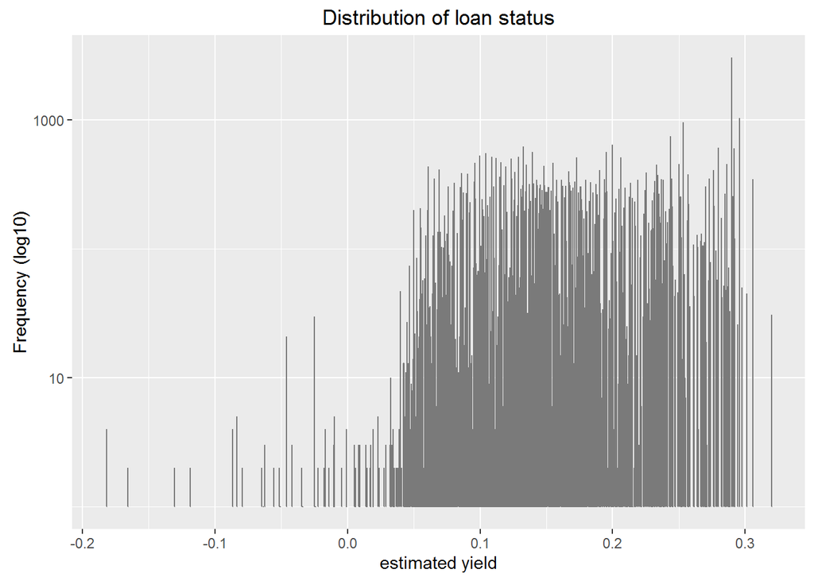

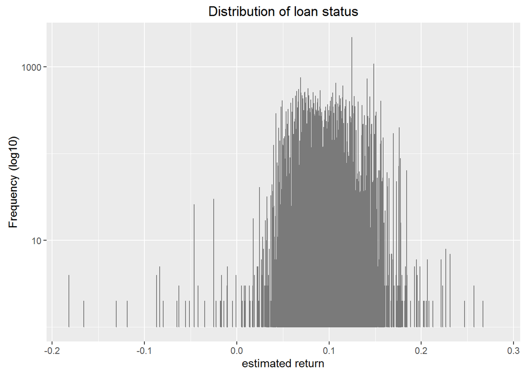

Most users have 0 accounts with deliquency. Up until now, the general profile of users indicates that I may be suitable for using this system.

## Bivariate Analysis

To analyze deeper, I wanted to see if I use this system, whether my employment status at that time (i.e. I may be employed or unemployed) affects my performance of this platform. I decided to estimate my performance using estimated loss, yield and return indicator (although return pretty much sums up the story, I still wanted to know what is going on inside.)

My speculation is that those who are not employed tend to have high estimated loss, low estimated yield and low estimated return.

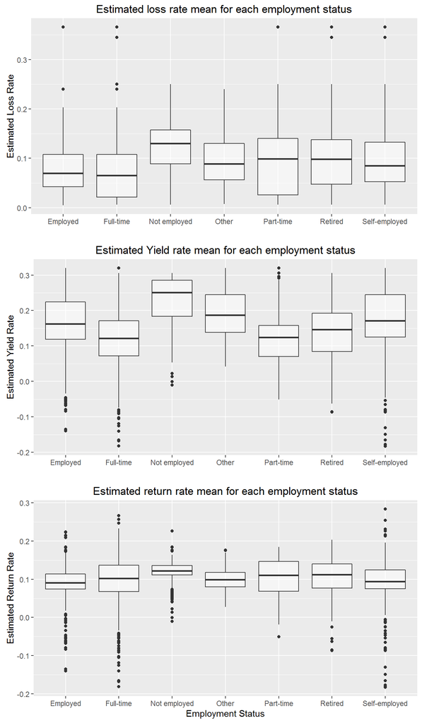

I was curious as to what will happen for EstimatedReturn. Surprisingly, those who are unemployed had high estimated return rate. At this point, I concluded that there is no correlation between employment status and estimated loss / return rate because they are not consistent. (e.g. it cannot be the case that unemployed people can have high loss AND return rate at the same time.)

From this comparison, it seems that there are correlation between estimated loss rate and estimated return rate.

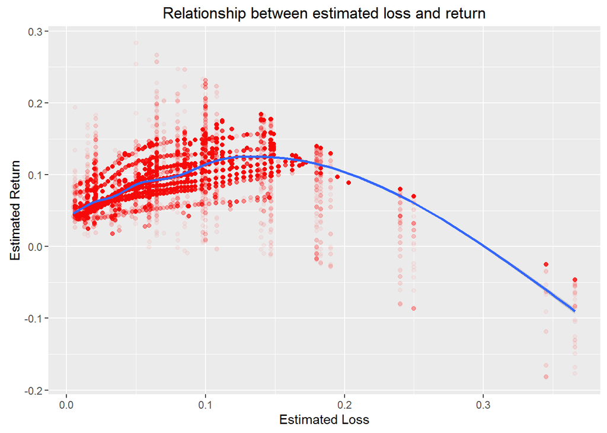

Now, I would like to know whether the employment status would be correlated with the loan status. This is very important because I would want my loan status to be completed. By looking completion frequencies for each employment status, I might be able to answer this important question.

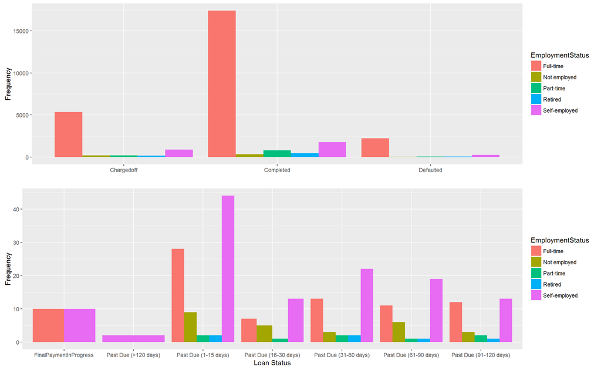

Please do not be fooled by count! It is not a good idea to compare data by employment status but rather how each employment status is distributed based on loan status. In overall, those whose finances are not secure tend not to use this Prosper P2P system (compared to full-time and self-employed). However, one thing to note is that although the total number of self-employed people are considerably lower than that of full-time people, they have high number of overdue profiles (they are the only people who are past due more than 120 days and for self-employed in every past due bar they are the highest.) If I start business, it may not be a good idea to use Prosper system as the likelihood of having overdue payment is significantly high.

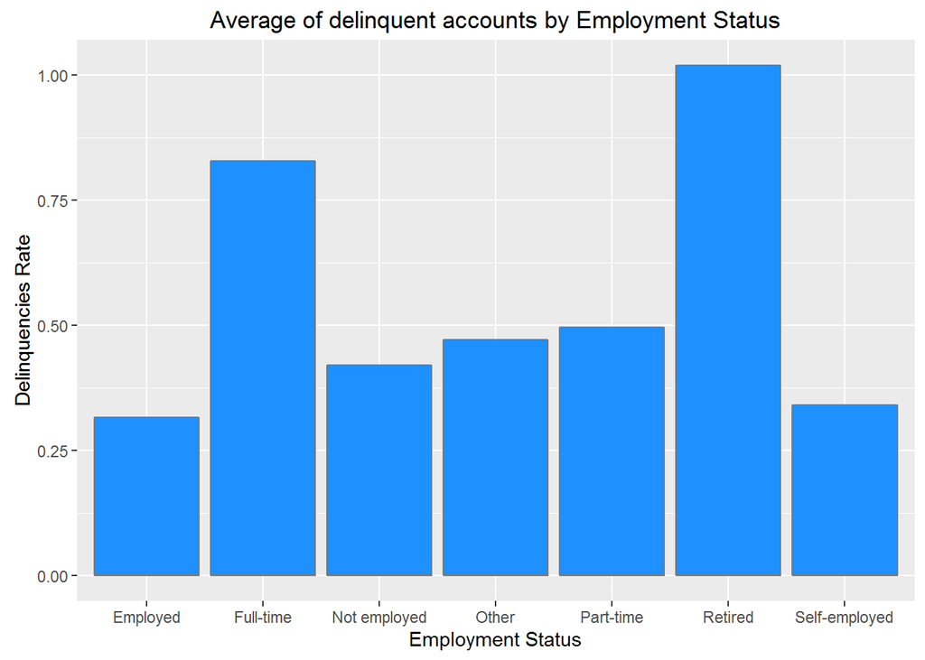

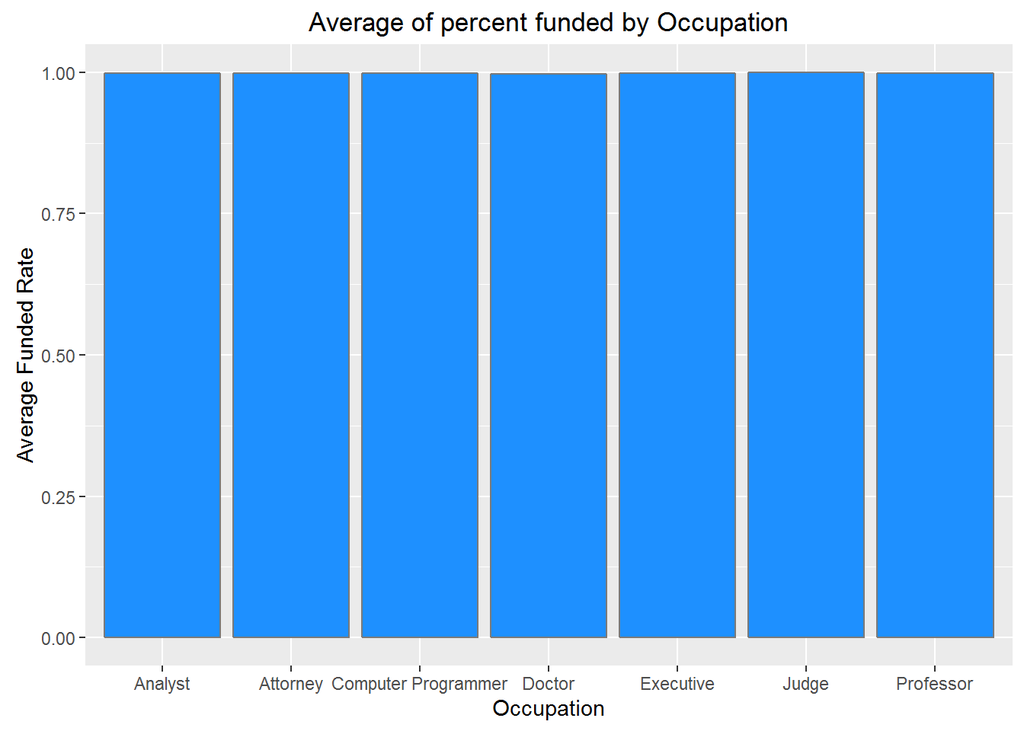

### Multivariate Analysis

We have seen how income range is correlated with the probability of one borrowing money using this platform. Therefore, it would be good to know: for each income range, how loan status and employment status are related together (interrelationship among the variables). I discarded ‘Not displayed’ and ‘Not employed’ in the facetting process because they are redundant for our purpose. Although $0 may be data to be cleaned, I included it in because it may reveal some useful insight to our analysis.

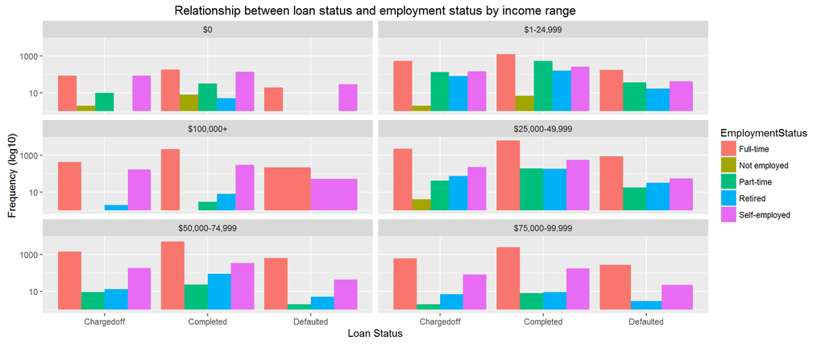

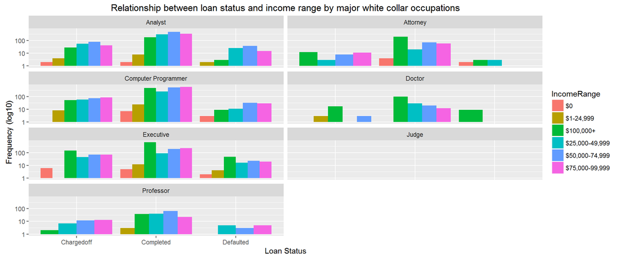

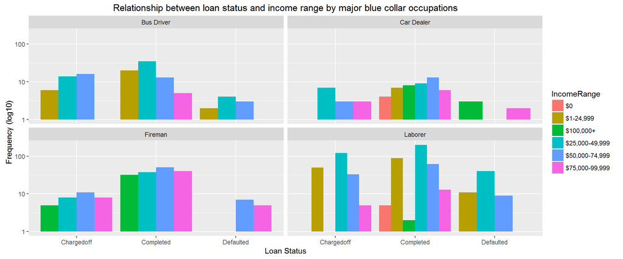

As these three plots suggest, regardless of one’s employment status and income range, most users were able to use the system without trouble as their loan status is ‘completed.’ Most users are, in fact, employed and amongst employed people, the white collar occupation does not have loan status problem (things do not really differ in terms of income range). However, for blue collar occupations like car dealer, depending on income range, it might tell us that his or her loan status may not be completed. However, as my future occupation is highly likely to fall under white collar occupations, these factors suggest to me that I should use Prosper system when needed because people in similar situation as me use the system generally without trouble.

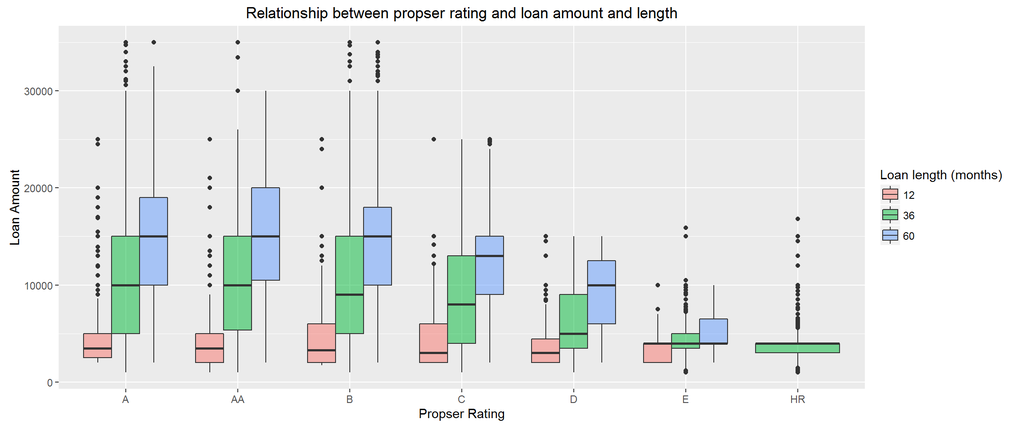

For good prosper ratings, loan amount and legnth do not differ. If compared with poor prosper rating, the average loan amount is significantly lower than that of entries with good ratings.

### Final Plots and Summary

The final three plots effectively summarize what I have explored so far. I would like to summarize my finding in the following three main aspects 1) Demographic aspect 2) Loan Status / Employment Status (income range) 3) Occupation (If employed) / Loan Status (income range).

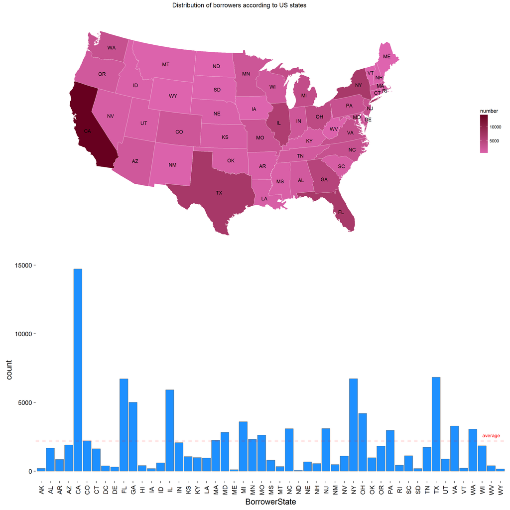

```r
#Total number of borrowers
nrow(pd)
```

```
## [1] 113937
```

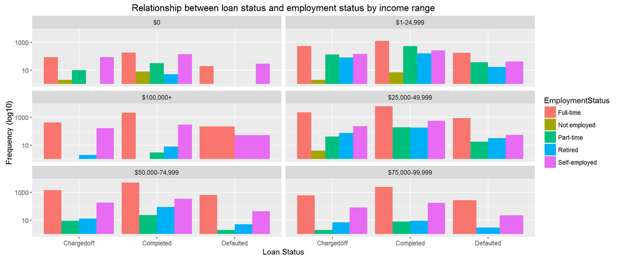

Another good determinant was income range and employment status of borrowers. In my case, it is very important that my loan status be completed. Regardless of income range and employment status, the loan status of borrowers is usually ‘completed.’ Furthermore, the borrowers who are employed full-time are mostly using the platform. One interesting observation is that borrowers who make more than 50K per annum are never unemployed (and they could earn up to $25,000 ~ $49,999 range). Compared to my profile, I am full-time worker having average income. As many users are in a similar situation, this data also indicates that I can use the system.

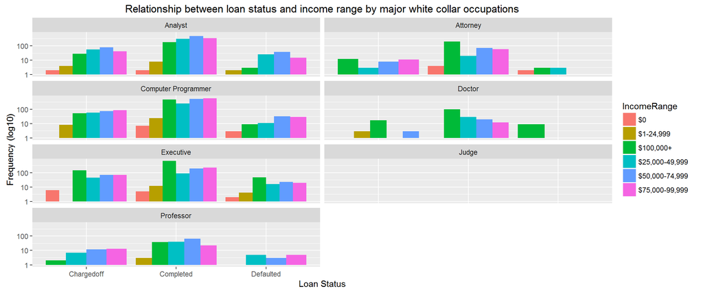

Since I have three ticks, I decided to use Prosper P2P platform when needed.

### Reflection

The fundamental difficult aspect of the analysis was the nature of dataset. I have never encountered the concept of P2P-based financial platform so it took a lot of time to understand the dataset. To deal with this, I went to Prosper website and learned about some financial concepts like delinquencies. Furthermore, the dataset contains many attributes and it was difficult to understand every attribute as the description of each attribute lacked details. However, as there were too many attributes to consider, I was not able to use every attribute so in the future, I would like to draw more interesting information from the dataset. I am sure there are more to be discovered. For instance, I can look at past data such as Trades Opened in the last 6 months and decide whether to use this platform or not. Considering more variables would strengthen the accuracy of my decision.